# Running *clusso* with Case-Control Data

# Introduction

This package is still under development. Please [report any bugs](https://github.com/mkamenet3/clusso/issues).

Load `clusso` package:

```r
library("clusso")
```

## Using `clusso` with case-control data

### Prepare Data

We load four datasets that comes with the `clusso` package:

```r
#load data
data("ccsjbc")
data("utmJapan")
data("japan.poly2")
data("japan.prefect2")
```

These datasets contain:

1. `ccsjbc`: data set containting a unique identifier for each centroid (*id*), period of observation (categorical variable with 5 levels, *period*), number of cases per each geographic unit (*numcases*), the total number of cases and controls from each geographic unit (*n*). These data are simulated.
2. `utmJapan`: data set containing a unique identifier for each centroid (*id*), x-coordinate in UTM (*utmx*), and y-coordinate in UTM (*utmy*)
3. `japan.poly2`: polygon tesselations
4. `japan.prefect2`: boundaries for the prefects (geographical boundaries) of the region.

To explore the 4 data sets, we apply the `head()` function to each of the data sets.

```r
#inspect
head(utmJapan)
```

```
##     id     utmx    utmy
## 1 9201 399786.6 4047756
## 2 9202 360917.0 4023885
## 3 9203 385175.1 4025749
## 4 9204 371603.4 4018172
## 5 9205 388154.2 4047900
## 6 9206 375023.3 4068053
```

```r
head(japan.poly2)
```

```
##         V1       V2
## 1 393.9011 4042.278
## 2 394.0569 4054.908
## 3 399.9345 4053.977
## 4 408.0074 4044.650
## 5 407.5330 4041.293
## 6 401.0393 4039.872
```

```r
head(japan.prefect2)
```

```
##         x1       y1       x2       y2
## 1 394.0274 4013.261 396.7974 4021.866
## 2 415.0914 4026.719 418.0050 4030.566
## 3 413.2195 4026.586 415.0914 4026.719
## 4 404.9966 4106.828 404.9219 4106.764
## 5 409.0339 4108.622 404.9966 4106.828
## 6 410.1325 4107.836 409.0339 4108.622
```

```r
head(ccsjbc)
```

```
##     id period numcases     n   covar1     covar2 covar3 covar4 covar5
## 1 9201   7906     2944 10050 458.5877 0.01894360     34      1      0
## 2 9201   7922     2997 10032 470.2921 0.08078908     40      1      0
## 3 9201   7938     3044 10128 490.6435 0.02267590     32      0      1
## 4 9201   7954     3031 10227 501.6789 0.03259346     35      0      0
## 5 9201   7970     2976  9739 531.8578 0.01600942     32      0      1
## 6 9202   7906     3097 10565 521.2707 0.05811436     31      0      0
```

```r
ccsjbc$period <- as.factor(ccsjbc$period)
```

### Set global conditions

When using `clusso`, there are certain global parameters that need to be set.

We take the easting and northing coordinates from the `utmJapan` dataset, set the easting coordinate, `utmx`, to `x` and the northing coordinate, `utmy`, to `y`. Each is divided by 1000 to change the scale from meters to kilometers.

```r
x <- utmJapan$utmx/1000
y <- utmJapan$utmy/1000
```

Below, we set the maximum radius for a cluster to 20 km (`rMax=20`) based on scientific knowledge of the area and our definition of a meaningful cluster, set the number of unique time periods to 5 (`Time=5`).

```r
rMax <- 20
Time <- 5
```

### Running the models

```r
head(ccsjbc)
```

```
##     id period numcases     n   covar1     covar2 covar3 covar4 covar5
## 1 9201   7906     2944 10050 458.5877 0.01894360     34      1      0
## 2 9201   7922     2997 10032 470.2921 0.08078908     40      1      0
## 3 9201   7938     3044 10128 490.6435 0.02267590     32      0      1
## 4 9201   7954     3031 10227 501.6789 0.03259346     35      0      0
## 5 9201   7970     2976  9739 531.8578 0.01600942     32      0      1
## 6 9202   7906     3097 10565 521.2707 0.05811436     31      0      0
```

```r
system.time(resrealccs <- clusso(df=ccsjbc, expected = n, observed = numcases,timeperiod = period,id=id,
                                 covars=FALSE, x= x,y = y, rMax =  rMax, utm=TRUE,
                                 analysis="both", model="binomial",maxclust=11))
```

```
## Running binomial both spatial and spatio-temporal model(s).
```

```
## Creating radius-based potential clusters
```

```
## No covariates found
```

```
## Number of potential clusters to scan through:  66870
```

```
## Path selection: information criteria
```

```
## Lasso complete - extracting estimates and paths
```

```
## No covariates found
```

```
## Number of potential clusters to scan through:  66870
```

```
## Path selection: information criteria
```

```
## Lasso complete - extracting estimates and paths
```

```
## Overdispersion estimate: 2169.4765
```

```
## The number of clusters selected by at least one criterion is equal to maxclust. You may want to increase maxclust.
## The number of clusters selected by at least one criterion is equal to maxclust. You may want to increase maxclust.
```

```
## No covariates found
```

```
## Number of potential clusters to scan through:  66870
```

```
## Path selection: information criteria
```

```
## Lasso complete - extracting estimates and paths
```

```
## No covariates found
```

```
## Number of potential clusters to scan through:  66870
```

```
## Path selection: information criteria
```

```
## Lasso complete - extracting estimates and paths
```

```
## Overdispersion estimate: 2169.4765
```

```
## The number of clusters selected by at least one criterion is equal to maxclust. You may want to increase maxclust.
## The number of clusters selected by at least one criterion is equal to maxclust. You may want to increase maxclust.
```

```
## All models ran successfully
```

```
##    user  system elapsed
##   55.58    0.55   70.83
```

```r
clussopretty(resrealccs, analysis="both", model="binomial",clusteridentify=FALSE)
```

```
##            model analysistype numclust.AIC numclust.AICc numclust.BIC
## 1       Binomial        Space           12            12           12
## 2       Binomial   Space-Time           12            12           12
## 3 Quasi-Binomial        Space           11            11           11
## 4 Quasi-Binomial   Space-Time           11            11           11
```

Lastly, we can create plots of the coefficient paths with the function `clussoplot()`:

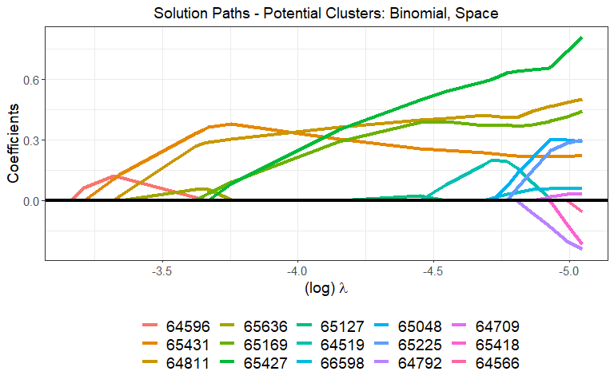

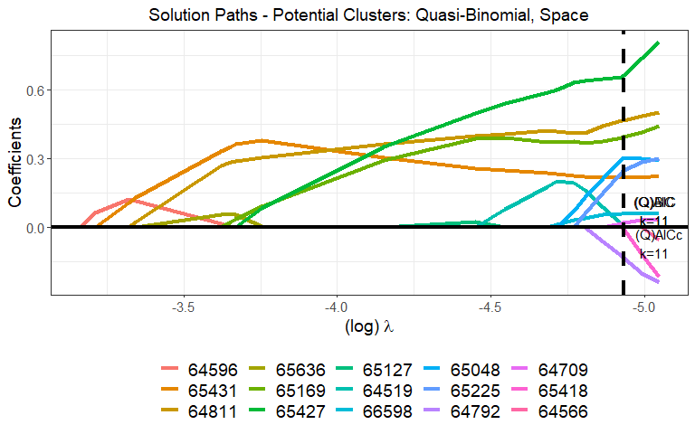

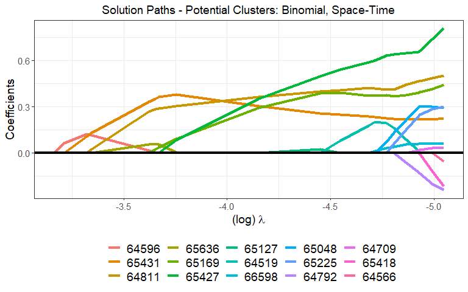

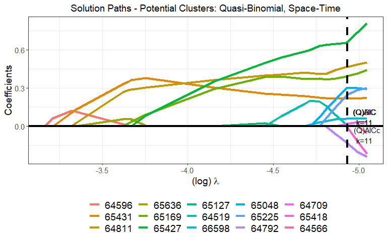

```r
clussoplot(resrealccs, analysis="both", model="binomial",Time=5)
```

## Comparison to Cross-Validation

We continue with the same dataset as above, but now explore results by $k$ fold cross-validation. All initial inputs are assumed to be the same.

```r
#perform clusso using cv (5 folds)
system.time(resccscv <- clusso(ccsjbc, expected = n, observed = numcases,timeperiod = period, id=id,
                               covars=FALSE, x= x,y = y, rMax =  rMax, utm=TRUE,
                               analysis="both", model="binomial",maxclust=11, cv=5))
```

```
## Running cross-validation method for path selection. For AIC, AICc, and BIC, set `cv = NULL`
```

```
## Running binomial both spatial and spatio-temporal model(s).
```

```
## Creating radius-based potential clusters
```

```
## No covariates found
```

```
## Number of potential clusters to scan through:  66870
```

```
## Path selection: cross-validation
```

```
## No covariates found
```

```
## Number of potential clusters to scan through:  66870
```

```
## Path selection: cross-validation
```

```
## No covariates found
```

```
## Number of potential clusters to scan through:  66870
```

```
## Path selection: cross-validation
```

```
## No covariates found
```

```
## Number of potential clusters to scan through:  66870
```

```
## Path selection: cross-validation
```

```
## All models ran successfully
```

```
##    user  system elapsed
##  163.58    1.56  186.79
```

```r
clussopretty(resccscv, analysis="both", model="binomial",clusteridentify=FALSE, cv=TRUE)
```

```
##            model analysistype numclust.cv
## 1       Binomial        Space          13
## 2       Binomial   Space-Time          13
## 3 Quasi-Binomial        Space          12
## 4 Quasi-Binomial   Space-Time          13
```

```
## In analysis Binomial, Space , number of detected clusters exceeds maxclust. Please increase maxclust and re-run clusso.
```

```
## In analysis Quasi-Binomial, Space , number of detected clusters exceeds maxclust. Please increase maxclust and re-run clusso.
```

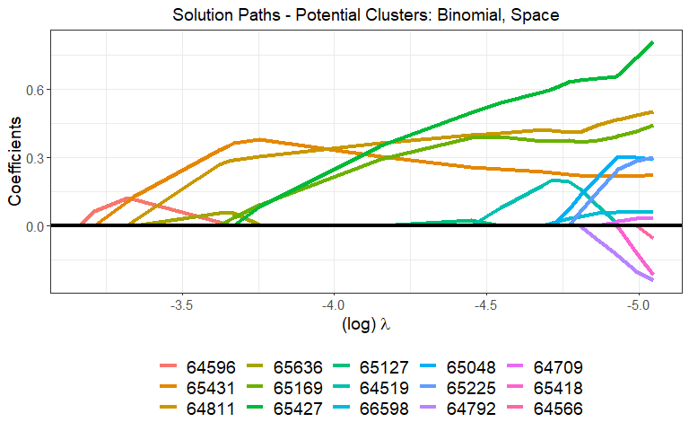

```
## In analysis Binomial, Space-Time , number of detected clusters exceeds maxclust. Please increase maxclust and re-run clusso.
```

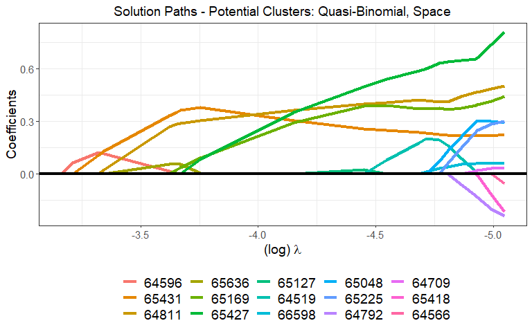

```
## In analysis Quasi-Binomial, Space-Time , number of detected clusters exceeds maxclust. Please increase maxclust and re-run clusso.
```

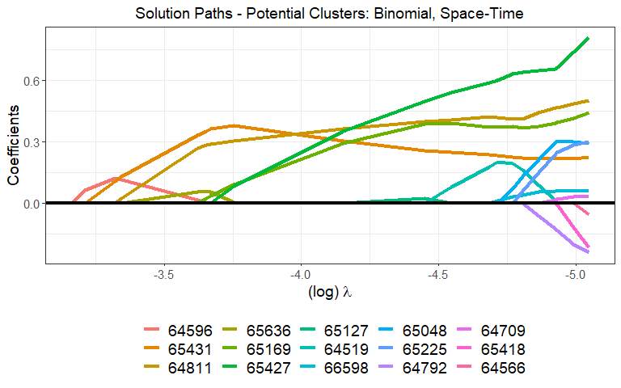

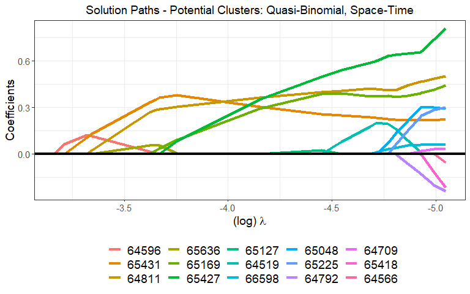

```r
clussoplot(resccscv, analysis="both",model="binomial", Time=5, cv=TRUE)
```

## Real Data Example with Covariates

We continue with the case-control data from Japan. We will again checkout the `head()` of the dataframe, `ccsjbc`.

```r
head(ccsjbc)
```

```
##     id period numcases     n   covar1     covar2 covar3 covar4 covar5
## 1 9201   7906     2944 10050 458.5877 0.01894360     34      1      0
## 2 9201   7922     2997 10032 470.2921 0.08078908     40      1      0
## 3 9201   7938     3044 10128 490.6435 0.02267590     32      0      1
## 4 9201   7954     3031 10227 501.6789 0.03259346     35      0      0
## 5 9201   7970     2976  9739 531.8578 0.01600942     32      0      1
## 6 9202   7906     3097 10565 521.2707 0.05811436     31      0      0
```

There are 5 additional covariates, `covar1` - `covar5` that we will want to adjust for as unpenalized terms in the LASSO.

We now set the argument `covars=TRUE` to tell `clusso()` to identify the covariates and to include them in as unpenalized terms in the LASSO model.

```r
system.time(resccscovars<- clusso(ccsjbc, expected = n, observed=numcases,timeperiod = period, id=id,
                                  covars=TRUE, x= x,y = y, rMax =  rMax, utm=TRUE,
                                  analysis="both", model="binomial",maxclust=11))
```

```
## Running binomial both spatial and spatio-temporal model(s).
```

```
## Creating radius-based potential clusters
```

```
## Running with covariates
```

```
## Number of potential clusters to scan through:  66870
```

```
## Path selection: information criteria
```

```
## Lasso complete - extracting estimates and paths
```

```
## Running with covariates
```

```
## Number of potential clusters to scan through:  66870
```

```
## Path selection: information criteria
```

```
## Lasso complete - extracting estimates and paths
```

```
## Overdispersion estimate: 2179.5856
```

```
## The number of clusters selected by at least one criterion is equal to maxclust. You may want to increase maxclust.
## The number of clusters selected by at least one criterion is equal to maxclust. You may want to increase maxclust.
```

```
## Running with covariates
```

```
## Number of potential clusters to scan through:  66870
```

```
## Path selection: information criteria
```

```
## Lasso complete - extracting estimates and paths
```

```
## Running with covariates
```

```
## Number of potential clusters to scan through:  66870
```

```
## Path selection: information criteria
```

```
## Lasso complete - extracting estimates and paths
```

```
## Overdispersion estimate: 2179.5856
```

```
## The number of clusters selected by at least one criterion is equal to maxclust. You may want to increase maxclust.
## The number of clusters selected by at least one criterion is equal to maxclust. You may want to increase maxclust.
```

```
## All models ran successfully
```

```
##    user  system elapsed
##   58.56    0.40   67.80
```

```r
clussopretty(resccscovars, analysis="both", model="binomial",clusteridentify = FALSE)
```

```
##            model analysistype numclust.AIC numclust.AICc numclust.BIC
## 1       Binomial        Space           12            12           12
## 2       Binomial   Space-Time           12            12           12
## 3 Quasi-Binomial        Space           11            11           11
## 4 Quasi-Binomial   Space-Time           11            11           11
```

We can also extract the coefficients for the unpenalized terms and undo the log-link by exponentiating:

```r
out <- clussopretty(resccscovars, analysis="both", model="poisson",covars=TRUE)
out$table.coefs
```

```
##         IC         model analysistype time_period1 time_period2 time_period3
## 1   (Q)AIC       Poisson        Space            0            0            0
## 2   (Q)AIC       Poisson   Space-Time            0            0            0
## 3   (Q)AIC       Poisson        Space            0            0            0
## 4   (Q)AIC       Poisson   Space-Time            0            0            0
## 5  (Q)AICc Quasi-Poisson        Space            0            0            0
## 6  (Q)AICc Quasi-Poisson   Space-Time            0            0            0
## 7  (Q)AICc Quasi-Poisson        Space            0            0            0
## 8  (Q)AICc Quasi-Poisson   Space-Time            0            0            0
## 9   (Q)BIC       Poisson        Space            0            0            0
## 10  (Q)BIC       Poisson   Space-Time            0            0            0
## 11  (Q)BIC       Poisson        Space            0            0            0
## 12  (Q)BIC       Poisson   Space-Time            0            0            0
## 13  (Q)AIC Quasi-Poisson        Space            0            0            0
## 14  (Q)AIC Quasi-Poisson   Space-Time            0            0            0
```

[output cut: 60 more lines]

```r
out$table.expcoefs
```

```
##         IC         model analysistype time_period1 time_period2 time_period3
## 1   (Q)AIC       Poisson        Space            1            1            1
## 2   (Q)AIC       Poisson   Space-Time            1            1            1
## 3   (Q)AIC       Poisson        Space            1            1            1
## 4   (Q)AIC       Poisson   Space-Time            1            1            1
## 5  (Q)AICc Quasi-Poisson        Space            1            1            1
## 6  (Q)AICc Quasi-Poisson   Space-Time            1            1            1
## 7  (Q)AICc Quasi-Poisson        Space            1            1            1
## 8  (Q)AICc Quasi-Poisson   Space-Time            1            1            1
## 9   (Q)BIC       Poisson        Space            1            1            1
## 10  (Q)BIC       Poisson   Space-Time            1            1            1
## 11  (Q)BIC       Poisson        Space            1            1            1
## 12  (Q)BIC       Poisson   Space-Time            1            1            1
## 13  (Q)AIC Quasi-Poisson        Space            1            1            1
## 14  (Q)AIC Quasi-Poisson   Space-Time            1            1            1
```

[output cut: 35 more lines]

```r
out$table.clusters
```

```
##           model analysistype numclust.AIC numclust.AICc numclust.BIC
## 1       Poisson        Space           12            12           12
## 2       Poisson   Space-Time           12            12           12
## 3 Quasi-Poisson        Space           11            11           11
## 4 Quasi-Poisson   Space-Time           11            11           11
```